# Support Vector Machine with Radial Basis Kernel using Package caret

# **5. 모형 훈련**

Package `"caret"`은 통합 API를 통해 R로 기계 학습을 실행할 수 있는 매우 실용적인 방법을 제공한다. Package `"caret"`에서는 초모수의 최적의 조합을 찾는 방법으로 그리드 검색(Grid Search), 랜덤 검색(Random Search), 직접 탐색 범위 설정이 있다. 여기서는 초모수 `sigma`, `C` (Cost)의 최적의 조합값을 찾기 위해 그리드 검색을 수행하였고, 이를 기반으로 직접 탐색 범위를 설정하였다. 아래는 그리드 검색을 수행하였을 때 결과이다.

```r
fitControl <- trainControl(method = "cv", number = 5,  # 5-Fold Cross Validation (5-Fold CV)
                           allowParallel = TRUE,       # 병렬 처리
                           classProbs = TRUE)          # For 예측 확률 생성

set.seed(100)                                          # For CV
svm.rd.fit <- train(Personal.Loan ~ ., data = UB.trd,
                    trControl = fitControl,
                    method = "svmRadial",
                    preProc = c("center", "scale"))    # Standardization for 예측 변수

svm.rd.fit
```

```
Support Vector Machines with Radial Basis Function Kernel

1751 samples
  21 predictor
   2 classes: 'no', 'yes'

Pre-processing: centered (21), scaled (21)
Resampling: Cross-Validated (5 fold)
Summary of sample sizes: 1401, 1401, 1400, 1401, 1401
Resampling results across tuning parameters:

  C     Accuracy   Kappa
  0.25  0.9640130  0.7993425
  0.50  0.9708685  0.8335374
  1.00  0.9754400  0.8591523

Tuning parameter 'sigma' was held constant at a value of 0.03323139
Accuracy was used to select the optimal model using the
 largest value.
The final values used for the model were sigma = 0.03323139 and C = 1.
```

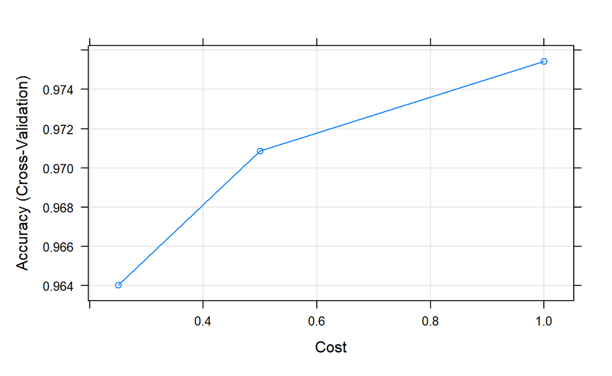

```r
plot(svm.rd.fit)                                       # plot
```

`Caution!` 함수 `train()`에 옵션 `method = "svmRadial"`을 입력하면 Package `"kernlab"`의 함수 `ksvm()`를 이용하여 Support Vector Machine을 수행한다. 해당 함수는 Kernel 함수가 `Radial Basis`일 때, 최적의 `sigma` 값을 자동으로 찾아준다.  
`Result!` 랜덤하게 결정된 3개의 초모수 `C` 값과 1개의 `sigma` 값을 조합하여 만든 3개의 초모수 조합값 (`sigma`, `C`)에 대한 정확도를 보여주며, (`sigma` = 0.03323139, `C` = 1)일 때 정확도가 가장 높은 것을 알 수 있다. 따라서 그리드 검색을 통해 찾은 최적의 초모수 조합값 (`sigma` = 0.03323139, `C` = 1) 근처의 값들을 탐색 범위로 설정하여 훈련을 다시 수행할 수 있다.

```r
customGrid <- expand.grid(sigma = seq(0.02, 0.04, 0.01), # sigma의 탐색 범위
                          C = 1:3)                       # C의 탐색 범위


set.seed(100)                                            # For CV
svm.rd.grid.fit <- train(Personal.Loan ~ ., data = UB.trd,
                         trControl = fitControl,
                         tuneGrid = customGrid,
                         method = "svmRadial",
                         preProc = c("center", "scale")) # Standardization for 예측 변수
svm.rd.grid.fit
```

```
Support Vector Machines with Radial Basis Function Kernel

1751 samples
  21 predictor
   2 classes: 'no', 'yes'

Pre-processing: centered (21), scaled (21)
Resampling: Cross-Validated (5 fold)
Summary of sample sizes: 1401, 1401, 1400, 1401, 1401
Resampling results across tuning parameters:

  sigma  C  Accuracy   Kappa
  0.02   1  0.9725828  0.8417210
  0.02   2  0.9760147  0.8617339
  0.02   3  0.9765861  0.8635022
  0.03   1  0.9731559  0.8461398
  0.03   2  0.9743020  0.8519862
  0.03   3  0.9748751  0.8550152
  0.04   1  0.9737257  0.8482358
  0.04   2  0.9737322  0.8497276
  0.04   3  0.9743036  0.8532982

Accuracy was used to select the optimal model using the
 largest value.
The final values used for the model were sigma = 0.02 and C = 3.
```

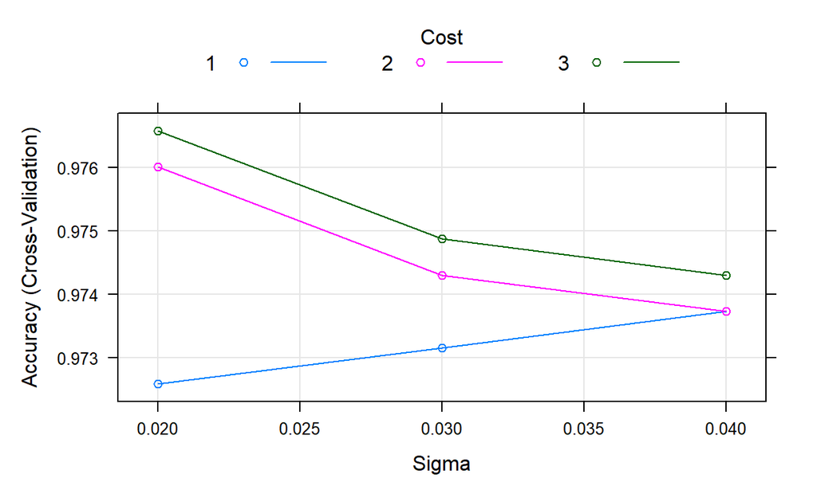

```r
plot(svm.rd.grid.fit)                                    # Plot
```

```r
svm.rd.grid.fit$bestTune                                 # 최적의 초모수 조합값
```

```
  sigma C
3  0.02 3
```

`Result!` (`sigma` = 0.02, `C` = 3)일 때 정확도가 가장 높다는 것을 알 수 있으며, (`sigma` = 0.02, `C` = 3)를 가지는 모형을 최적의 훈련된 모형으로 선택한다.

# **6. 모형 평가**

`Caution!` 모형 평가를 위해 `Test Dataset`에 대한 `예측 class/확률` 이 필요하며, 함수 `predict()`를 이용하여 생성한다.

```r
# 예측 class 생성
svm.rd.pred <- predict(svm.rd.grid.fit,
                       newdata = UB.ted[,-1])            # Test Dataset including Only 예측 변수

svm.rd.pred %>%
  as_tibble
```

```
# A tibble: 749 × 1
   value
   <fct>
 1 no
 2 no
 3 no
 4 no
 5 no
 6 no
 7 no
 8 no
 9 no
10 no
# ℹ 739 more rows
```

## **6-1. ConfusionMatrix**

```r
CM   <- caret::confusionMatrix(svm.rd.pred, UB.ted$Personal.Loan,
                               positive = "yes")         # confusionMatrix(예측 class, 실제 class, positive = "관심 class")
CM
```

```
Confusion Matrix and Statistics

          Reference
Prediction  no yes
       no  669  14
       yes   4  62

               Accuracy : 0.976
                 95% CI : (0.9623, 0.9857)
    No Information Rate : 0.8985
    P-Value [Acc > NIR] : < 2e-16

                  Kappa : 0.86

 Mcnemar's Test P-Value : 0.03389

            Sensitivity : 0.81579
            Specificity : 0.99406
         Pos Pred Value : 0.93939
         Neg Pred Value : 0.97950
             Prevalence : 0.10147
         Detection Rate : 0.08278
   Detection Prevalence : 0.08812
      Balanced Accuracy : 0.90492

       'Positive' Class : yes
```

## **6-2. ROC 곡선**

```r
# 예측 확률 생성
test.svm.prob <- predict(svm.rd.grid.fit,
                         newdata = UB.ted[,-1],          # Test Dataset including Only 예측 변수
                         type = "prob")                  # 예측 확률 생성

test.svm.prob %>%
  as_tibble
```

```
# A tibble: 749 × 2
      no       yes
   <dbl>     <dbl>
 1 0.998 0.00221
 2 1.00  0.0000217
 3 1.00  0.0000142
 4 1.00  0.0000868
 5 1.00  0.0000108
 6 1.00  0.000139
 7 1.00  0.000108
 8 0.995 0.00496
 9 0.930 0.0702
10 0.999 0.000530
# ℹ 739 more rows
```

```r
test.svm.prob <- test.svm.prob[,2]                       # "Personal.Loan = yes"에 대한 예측 확률

ac  <- UB.ted$Personal.Loan                              # Test Dataset의 실제 class
pp  <- as.numeric(test.svm.prob)                         # 예측 확률을 수치형으로 변환
```

### **1) Package “pROC”**

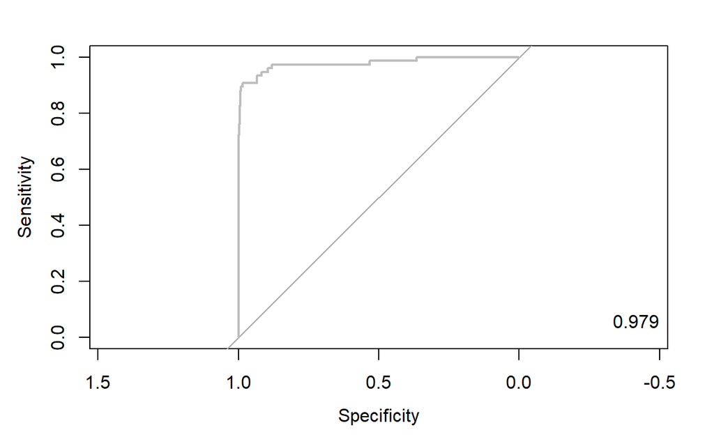

```r
pacman::p_load("pROC")

svm.roc  <- roc(ac, pp, plot = T, col = "gray")          # roc(실제 class, 예측 확률)
auc      <- round(auc(svm.roc), 3)
legend("bottomright", legend = auc, bty = "n")
```

`Caution!` Package `"pROC"`를 통해 출력한 ROC 곡선은 다양한 함수를 이용해서 그래프를 수정할 수 있다.

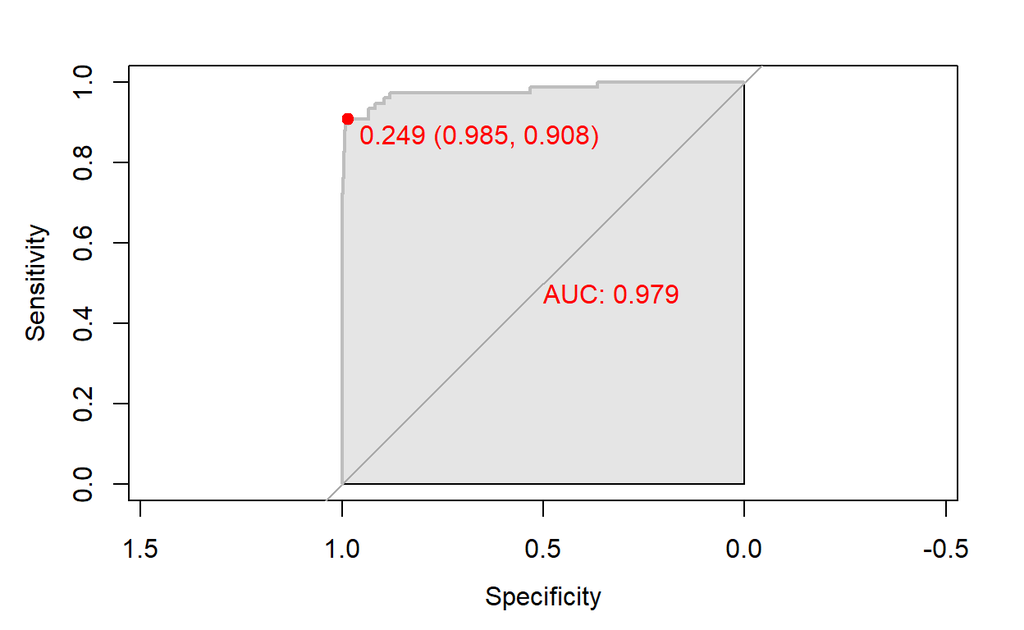

```r
# 함수 plot.roc() 이용
plot.roc(svm.roc,
         col="gray",                                     # Line Color
         print.auc = TRUE,                               # AUC 출력 여부
         print.auc.col = "red",                          # AUC 글씨 색깔
         print.thres = TRUE,                             # Cutoff Value 출력 여부
         print.thres.pch = 19,                           # Cutoff Value를 표시하는 도형 모양
         print.thres.col = "red",                        # Cutoff Value를 표시하는 도형의 색깔
         auc.polygon = TRUE,                             # 곡선 아래 면적에 대한 여부
         auc.polygon.col = "gray90")                     # 곡선 아래 면적의 색깔
```

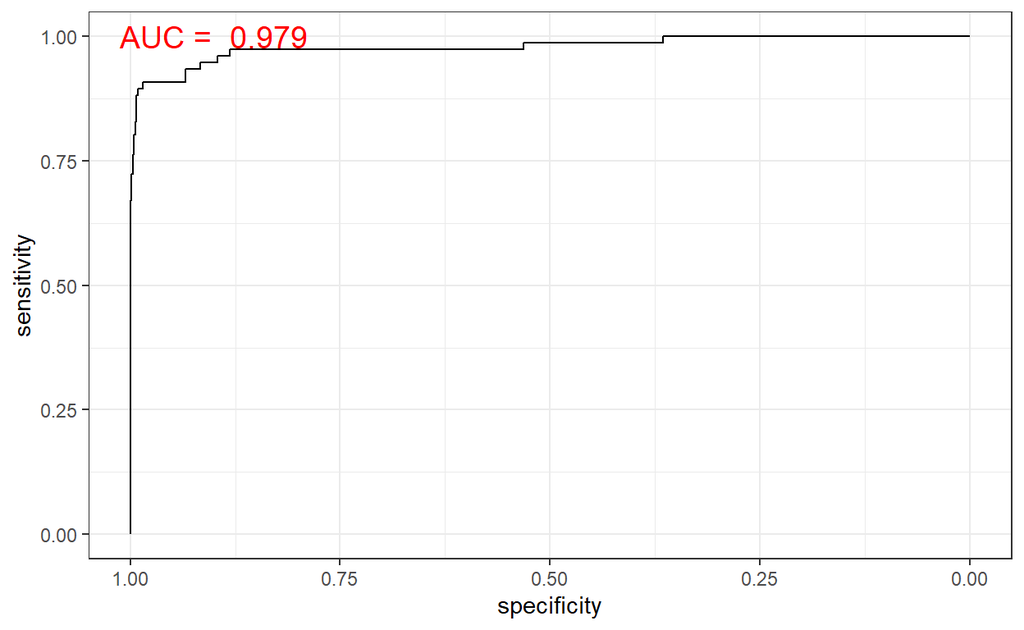

```r
# 함수 ggroc() 이용
ggroc(svm.roc) +
annotate(geom = "text", x = 0.9, y = 1.0,
label = paste("AUC = ", auc),
size = 5,
color="red") +
theme_bw()
```

### **2) Package “Epi”**

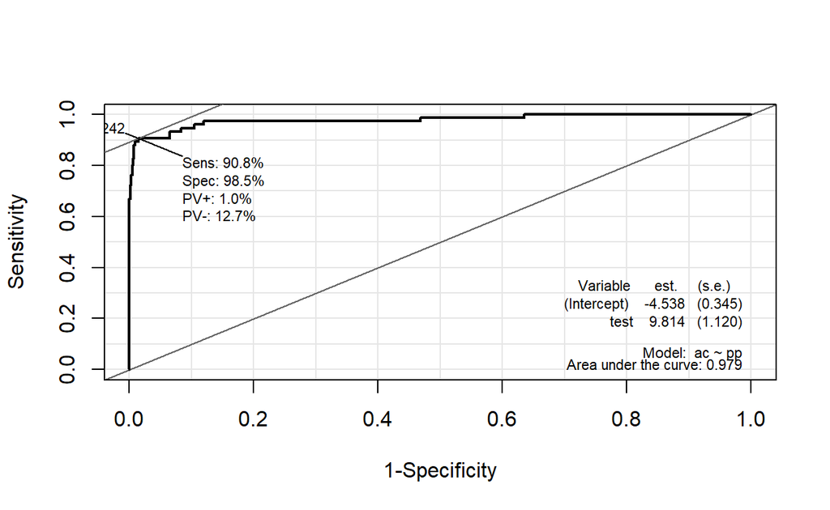

```r
pacman::p_load("Epi")
# install_version("etm", version = "1.1", repos = "http://cran.us.r-project.org")

ROC(pp, ac, plot = "ROC")                                # ROC(예측 확률, 실제 class)
```

### **3) Package “ROCR”**

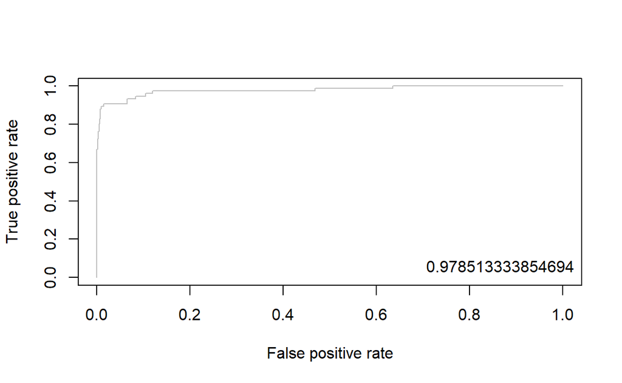

```r
pacman::p_load("ROCR")

svm.pred <- prediction(pp, ac)                           # prediction(예측 확률, 실제 class)

svm.perf <- performance(svm.pred, "tpr", "fpr")          # performance(, "민감도", "1-특이도")
plot(svm.perf, col = "gray")                             # ROC Curve

perf.auc   <- performance(svm.pred, "auc")               # AUC
auc        <- attributes(perf.auc)$y.values
legend("bottomright", legend = auc, bty = "n")
```

## **6-3. 향상 차트**

### **1) Package “ROCR”**

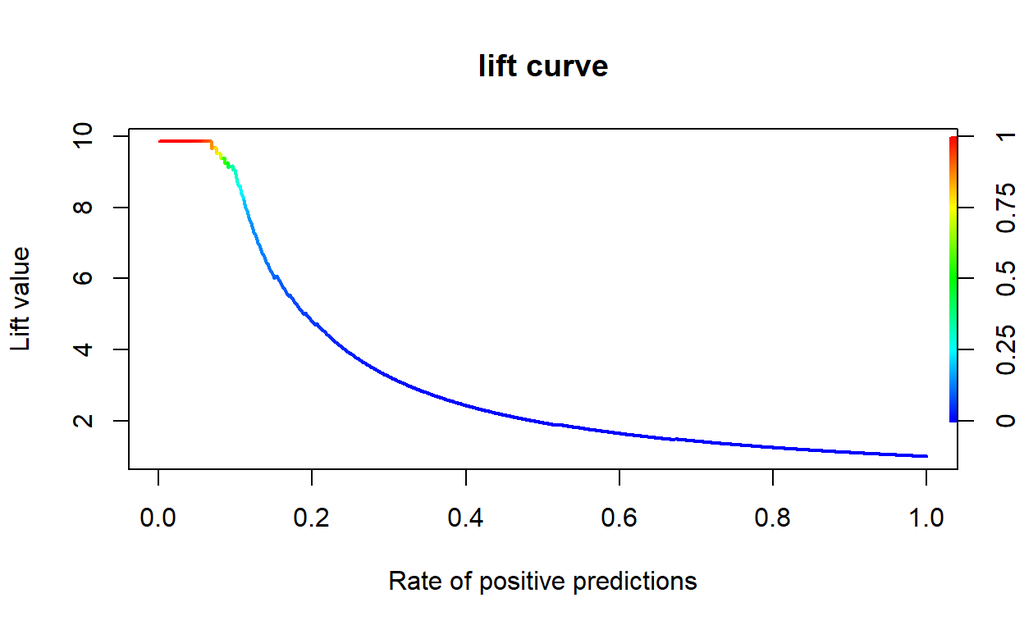

```r
svm.perf <- performance(svm.pred, "lift", "rpp")         # Lift Chart
plot(svm.perf, main = "lift curve",
     colorize = T,                                       # Coloring according to cutoff
     lwd = 2)
```